```r
knitr::opts_chunk$set(
  echo = TRUE,
  message = FALSE,
  warning = FALSE,
  fig.width = 9,
  fig.height = 6
)

set.seed(123)
```

1. Introduction

This project analyzes cyberbullying tweets using text mining and machine learning. The dataset contains tweets classified into six categories: age, ethnicity, gender, not cyberbullying, other cyberbullying, and religion.

The main objectives are to clean the dataset, explore word frequencies, calculate TF-IDF scores, train Logistic Regression and Support Vector Machine (SVM) classifiers, evaluate their performance, compare the models, and export the results.

2. Install and Load Required Packages

Install the required packages only once. If a package is missing, the following code installs it automatically.

```r
packages <- c(
  "dplyr", "stringr", "tidytext", "ggplot2",
  "caret", "Matrix", "tm", "glmnet",
  "text2vec", "LiblineaR", "tidyr", "knitr"
)

missing_packages <- packages[
  !vapply(packages, requireNamespace, logical(1), quietly = TRUE)
]

if (length(missing_packages) > 0) {
  install.packages(missing_packages, repos = "https://cloud.r-project.org")
}

invisible(lapply(packages, library, character.only = TRUE))
```

3. Load the Dataset

Update file_path if the CSV file is stored in another location. Use forward slashes in the Windows path.

```r
file_path <- "C:/Users/M SANIYA MUNTAZ/Downloads/datascience/cyberbullying_tweets ds.csv"

if (!file.exists(file_path)) {
  stop("Dataset not found. Please check and update file_path.")
}

data <- read.csv(
  file_path,
  stringsAsFactors = FALSE
)

required_columns <- c("tweet_text", "cyberbullying_type")

if (!all(required_columns %in% names(data))) {
  stop("The dataset must contain tweet_text and cyberbullying_type columns.")
}

cat("Dataset dimensions:", dim(data), "\n")
```

```
## Dataset dimensions: 47692 2
```

```r
head(data)
```

```
##                                                                                                                            tweet_text
## 1                                                                       In other words #katandandre, your food was crapilicious! #mkr
## 2                 Why is #aussietv so white? #MKR #theblock #ImACelebrityAU #today #sunrise #studio10 #Neighbours #WonderlandTen #etc
## 3                                                                        @XochitlSuckkks a classy whore? Or more red velvet cupcakes?
## 4                             @Jason_Gio meh. :P  thanks for the heads up, but not too concerned about another angry dude on twitter.
## 5                             @RudhoeEnglish This is an ISIS account pretending to be a Kurdish account.  Like Islam, it is all lies.
## 6 @Raja5aab @Quickieleaks Yes, the test of god is that good or bad or indifferent or weird or whatever, it all proves gods existence.
##   cyberbullying_type
## 1  not_cyberbullying
## 2  not_cyberbullying
## 3  not_cyberbullying
## 4  not_cyberbullying
## 5  not_cyberbullying
## 6  not_cyberbullying
```

```r
names(data)
```

```
## [1] "tweet_text"         "cyberbullying_type"
```

```r
str(data)
```

```
## 'data.frame':    47692 obs. of  2 variables:
##  $ tweet_text        : chr  "In other words #katandandre, your food was crapilicious! #mkr" "Why is #aussietv so white? #MKR #theblock #ImACelebrityAU #today #sunrise #studio10 #Neighbours #WonderlandTen #etc" "@XochitlSuckkks a classy whore? Or more red velvet cupcakes?" "@Jason_Gio meh. :P  tha…
##  $ cyberbullying_type: chr  "not_cyberbullying" "not_cyberbullying" "not_cyberbullying" "not_cyberbullying" ...
```

3.1 Category Distribution

The category distribution shows the number of tweets belonging to each cyberbullying class.

```r
category_counts <- data %>%
  count(cyberbullying_type, name = "Count")

knitr::kable(category_counts)
```

| cyberbullying_type | Count |
| --- | --- |
| age | 7992 |
| ethnicity | 7961 |
| gender | 7973 |
| not_cyberbullying | 7945 |
| other_cyberbullying | 7823 |
| religion | 7998 |

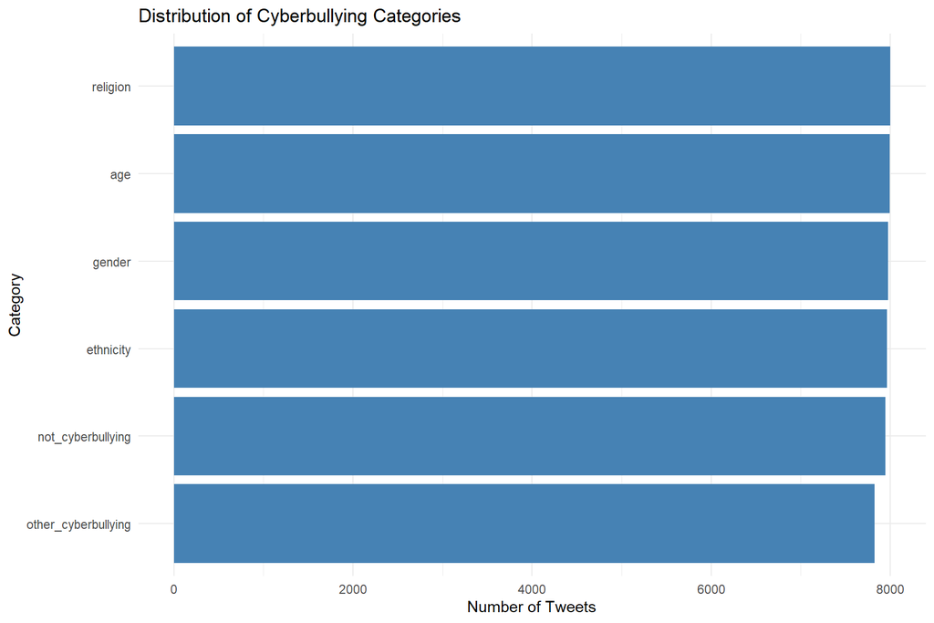

```r
ggplot(
  category_counts,
  aes(
    x = reorder(cyberbullying_type, Count),
    y = Count
  )
) +
  geom_col(fill = "steelblue") +
  coord_flip() +
  labs(
    title = "Distribution of Cyberbullying Categories",
    x = "Category",
    y = "Number of Tweets"
  ) +
  theme_minimal()
```

3.2 Missing Values and Duplicates

```r
colSums(is.na(data))
```

```
##         tweet_text cyberbullying_type
##                  0                  0
```

```r
cat(
  "Duplicate original tweets:",
  sum(duplicated(data$tweet_text)),
  "\n"
)
```

```
## Duplicate original tweets: 1675
```

```r
table(data$cyberbullying_type, useNA = "ifany")
```

```
##
##                 age           ethnicity              gender   not_cyberbullying
##                7992                7961                7973                7945
## other_cyberbullying            religion
##                7823                7998
```

4. Data Cleaning 4.1 Remove Missing, Empty, and Duplicate Tweets

The original dataset remains unchanged. A separate object, clean_data, is created for cleaning.

```r
clean_data <- data %>%
  filter(
    !is.na(tweet_text),
    !is.na(cyberbullying_type)
  ) %>%
  mutate(
    tweet_text = as.character(tweet_text),
    cyberbullying_type = as.character(cyberbullying_type)
  ) %>%
  filter(trimws(tweet_text) != "") %>%
  distinct(tweet_text, .keep_all = TRUE)

cat("Cleaned dataset dimensions:", dim(clean_data), "\n")
```

```
## Cleaned dataset dimensions: 46017 2
```

```r
cat(
  "Remaining duplicate original tweets:",
  sum(duplicated(clean_data$tweet_text)),
  "\n"
)
```

```
## Remaining duplicate original tweets: 0
```

```r
table(clean_data$cyberbullying_type)
```

```
##
##                 age           ethnicity              gender   not_cyberbullying
##                7992                7952                7898                7937
## other_cyberbullying            religion
##                6243                7995
```

4.2 Create Binary Category Columns

Each category receives a separate binary column. A value of 1 means that the tweet belongs to that category; otherwise, the value is 0.

```r
categories <- c(
  "age",
  "ethnicity",
  "gender",
  "not_cyberbullying",
  "other_cyberbullying",
  "religion"
)

unexpected_categories <- setdiff(
  unique(clean_data$cyberbullying_type),
  categories
)

if (length(unexpected_categories) > 0) {
  stop(
    "Unexpected category labels: ",
    paste(unexpected_categories, collapse = ", ")
  )
}

for (category in categories) {
  clean_data[[category]] <- as.integer(
    clean_data$cyberbullying_type == category
  )
}

dim(clean_data)
```

```
## [1] 46017     8
```

```r
names(clean_data)
```

```
## [1] "tweet_text"          "cyberbullying_type"  "age"
## [4] "ethnicity"           "gender"              "not_cyberbullying"
## [7] "other_cyberbullying" "religion"
```

```r
head(clean_data)
```

```
##                                                                                                                            tweet_text
## 1                                                                       In other words #katandandre, your food was crapilicious! #mkr
## 2                 Why is #aussietv so white? #MKR #theblock #ImACelebrityAU #today #sunrise #studio10 #Neighbours #WonderlandTen #etc
## 3                                                                        @XochitlSuckkks a classy whore? Or more red velvet cupcakes?
## 4                             @Jason_Gio meh. :P  thanks for the heads up, but not too concerned about another angry dude on twitter.
## 5                             @RudhoeEnglish This is an ISIS account pretending to be a Kurdish account.  Like Islam, it is all lies.
## 6 @Raja5aab @Quickieleaks Yes, the test of god is that good or bad or indifferent or weird or whatever, it all proves gods existence.
##   cyberbullying_type age ethnicity gender not_cyberbullying other_cyberbullying
## 1  not_cyberbullying   0         0      0                 1                   0
## 2  not_cyberbullying   0         0      0                 1                   0
## 3  not_cyberbullying   0         0      0                 1                   0
## 4  not_cyberbullying   0         0      0                 1                   0
## 5  not_cyberbullying   0         0      0                 1                   0
## 6  not_cyberbullying   0         0      0                 1                   0
##   religion
## 1        0
## 2        0
## 3        0
## 4        0
## 5        0
## 6        0
```

4.3 Text Preprocessing

Text preprocessing converts tweets to lowercase, removes URLs and usernames, replaces punctuation and numbers with spaces, and removes extra whitespace.

```r
clean_data <- clean_data %>%
  mutate(
    tweet_clean = str_to_lower(tweet_text),
    tweet_clean = str_remove_all(
      tweet_clean,
      "https?://\\S+|www\\.\\S+"
    ),
    tweet_clean = str_remove_all(
      tweet_clean,
      "@\\w+"
    ),
    tweet_clean = str_replace_all(
      tweet_clean,
      "[^a-z\\s]",
      " "
    ),
    tweet_clean = str_squish(tweet_clean)
  ) %>%
  filter(
    !is.na(tweet_clean),
    tweet_clean != ""
  ) %>%
  distinct(tweet_clean, .keep_all = TRUE) %>%
  mutate(tweet_id = row_number())

head(clean_data[, c("tweet_text", "tweet_clean")], 10)
```

```
##                                                                                                                             tweet_text
## 1                                                                        In other words #katandandre, your food was crapilicious! #mkr
## 2                  Why is #aussietv so white? #MKR #theblock #ImACelebrityAU #today #sunrise #studio10 #Neighbours #WonderlandTen #etc
## 3                                                                         @XochitlSuckkks a classy whore? Or more red velvet cupcakes?
## 4                              @Jason_Gio meh. :P  thanks for the heads up, but not too concerned about another angry dude on twitter.
## 5                              @RudhoeEnglish This is an ISIS account pretending to be a Kurdish account.  Like Islam, it is all lies.
## 6  @Raja5aab @Quickieleaks Yes, the test of god is that good or bad or indifferent or weird or whatever, it all proves gods existence.
## 7                                                                               Itu sekolah ya bukan tempat bully! Ga jauh kaya neraka
## 8                                                                      Karma. I hope it bites Kat on the butt. She is just nasty. #mkr
## 9                                                                                         @stockputout everything but mostly my priest
## 10                                                                                  Rebecca Black Drops Out of School Due to Bullying:
##                                                                                                 tweet_clean
## 1                                                 in other words katandandre your food was crapilicious mkr
## 2    why is aussietv so white mkr theblock imacelebrityau today sunrise studio neighbours wonderlandten etc
## 3                                                                a classy whore or more red velvet cupcakes
## 4                   meh p thanks for the heads up but not too concerned about another angry dude on twitter
## 5                      this is an isis account pretending to be a kurdish account like islam it is all lies
## 6  yes the test of god is that good or bad or indifferent or weird or whatever it all proves gods existence
## 7                                                     itu sekolah ya bukan tempat bully ga jauh kaya neraka
## 8                                               karma i hope it bites kat on the butt she is just nasty mkr
## 9                                                                           everything but mostly my priest
## 10                                                        rebecca black drops out of school due to bullying
```

```r
cat("Final cleaned dimensions:", dim(clean_data), "\n")
```

```
## Final cleaned dimensions: 45003 10
```

```r
cat(
  "Missing cleaned tweets:",
  sum(is.na(clean_data$tweet_clean)),
  "\n"
)
```

```
## Missing cleaned tweets: 0
```

```r
cat(
  "Empty cleaned tweets:",
  sum(clean_data$tweet_clean == ""),
  "\n"
)
```

```
## Empty cleaned tweets: 0
```

5. Exploratory Data Analysis 5.1 Shuffle the Dataset

Shuffling randomizes row order without changing the tweet labels.

```r
set.seed(123)

clean_data <- clean_data[
  sample(seq_len(nrow(clean_data))),
  ,
  drop = FALSE
]

rownames(clean_data) <- NULL

head(clean_data, 10)
```

```
##                                                                                                                                                                                                                                                                                tweet_text
## 1                                                                                                                                                                         Kiddies have written 15 Christmas cards each... only another 48 each to go and that's only the ones for school!
## 2                                                                                                                                                                         Donald Trump was that bully in elementary school who would tattletale to the teacher if anyone stood up to him.
## 3                                                                                                                                                                                                                middle school white girl bullies named britney in disney movies be like:
## 4                                                                                                                                                                                 RT @NickoleMariee BITCH !!!! Do you wanna die???? “@tayyoung_: FUCK OBAMA, dumb ass nigger” get her lol
## 5                                                                                                                                                                                                                                     Or their stupid hoe stories https://t.co/L6cP7LPdoe
## 6  (Acts 29:20490) BY none other than Satan, who is the great dragon, that old white snake serpent called the Devil and Satan and Lucifer and Jesus Christ, see Revelation 12:9, and they made "babies" by God's divine dark skinned "Golden" Negro Hebrew women on this world which they
## 7                                                y’all im pissed how mobile legend players say shit abt gays and how disrepectful they are to the gay community. also, rape jokes will never be funny and stop telling people to get COVID-19 if they’re not that good. grow the fuck up.
## 8      LMFAO I just came across a YouTube video of a girl I used to go to high school with exposing people from my high school bc she thought they bullied her but she was the real bully HAHA I am dying rn why does she make this video 5 years later Haha wow ppl really don't grow up
## 9                                                                                                                                                                                        RT @KrisTRealest @Matt_Camps Sum things jus aren't right coming from a girl'z lips... #NotSexist
## 10                It’s because, from personal experience, “females” has been the replacement for “bitches” by the shitty men who’ve been asked not to call me/us that so they essentially ruined the word for any respectful man bc now all we hear is the shitty connotation it now has.
##    cyberbullying_type age ethnicity gender not_cyberbullying
## 1   not_cyberbullying   0         0      0                 1
## 2                 age   1         0      0                 0
## 3                 age   1         0      0                 0
```

[output cut: 40 more lines]

```r
table(clean_data$cyberbullying_type)
```

```
##
##                 age           ethnicity              gender   not_cyberbullying
##                7934                7828                7651                7720
## other_cyberbullying            religion
##                5909                7961
```

```r
dim(clean_data)
```

```
## [1] 45003    10
```

5.2 Tokenize Tweets

Tokenization splits each tweet into individual words.

```r
tokens <- clean_data %>%
  select(tweet_id, cyberbullying_type, tweet_clean) %>%
  tidytext::unnest_tokens(word, tweet_clean)

head(tokens, 20)
```

```
##    tweet_id cyberbullying_type      word
## 1      2986  not_cyberbullying   kiddies
## 2      2986  not_cyberbullying      have
## 3      2986  not_cyberbullying   written
## 4      2986  not_cyberbullying christmas
## 5      2986  not_cyberbullying     cards
## 6      2986  not_cyberbullying      each
## 7      2986  not_cyberbullying      only
## 8      2986  not_cyberbullying   another
## 9      2986  not_cyberbullying      each
## 10     2986  not_cyberbullying        to
## 11     2986  not_cyberbullying        go
## 12     2986  not_cyberbullying       and
## 13     2986  not_cyberbullying      that
## 14     2986  not_cyberbullying         s
## 15     2986  not_cyberbullying      only
## 16     2986  not_cyberbullying       the
## 17     2986  not_cyberbullying      ones
## 18     2986  not_cyberbullying       for
## 19     2986  not_cyberbullying    school
## 20    29925                age    donald
```

```r
cat("Total word tokens:", nrow(tokens), "\n")
```

```
## Total word tokens: 1095369
```

5.3 Remove Stop Words

Stop words are common words such as “the”, “is”, and “and”. Removing them helps highlight more informative words.

data(“stop_words”, package = “tidytext”)

tokens_clean <- tokens %>% anti_join(stop_words, by = “word”) %>% filter( nchar(word) >= 3, !grepl(“^https?$”, word) )

head(tokens_clean, 20)

cat(“Tokens after stop-word removal:”, nrow(tokens_clean), “”)

top_words <- word_frequency %>% slice_max( order_by = n, n = 20, with_ties = FALSE )

knitr::kable(top_words)

top_words_by_category <- category_word_frequency %>% group_by(cyberbullying_type) %>% slice_max( order_by = n, n = 10, with_ties = FALSE ) %>% ungroup()

knitr::kable(top_words_by_category)

6. TF-IDF Analysis

Term Frequency–Inverse Document Frequency (TF-IDF) gives higher weights to words that are frequent in a document but less common across other documents.

head(tfidf_data)

highest_tfidf <- tfidf_data %>% arrange(desc(tf_idf)) %>% select( tweet_id, cyberbullying_type, word, tf, idf, tf_idf ) %>% head(10)

knitr::kable(highest_tfidf)

summary(tfidf_data$tf) summary(tfidf_data$idf) summary(tfidf_data$tf_idf)

6.2 Words with Highest Average TF-IDF

Only words appearing in at least 50 distinct tweets are included.

average_tfidf <- tfidf_data %>% group_by(word) %>% summarise( average_tfidf = mean(tf_idf), document_count = n_distinct(tweet_id), .groups = “drop” )

common_tfidf_words <- average_tfidf %>% filter(document_count >= 50) %>% slice_max( order_by = average_tfidf, n = 20, with_ties = FALSE )

knitr::kable(common_tfidf_words)

6.3 Category-Level TF-IDF

Category-level TF-IDF highlights words that are relatively distinctive to a category.

category_tfidf <- tokens_clean %>% count(cyberbullying_type, word, name = “n”) %>% tidytext::bind_tf_idf( term = word, document = cyberbullying_type, n = n )

word_tweet_counts <- tokens_clean %>% distinct(tweet_id, word) %>% count(word, name = “tweet_count”)

category_tfidf_filtered <- category_tfidf %>% inner_join(word_tweet_counts, by = “word”) %>% filter(tweet_count >= 20)

top_category_tfidf <- category_tfidf_filtered %>% group_by(cyberbullying_type) %>% slice_max( order_by = tf_idf, n = 10, with_ties = FALSE ) %>% ungroup()

knitr::kable( top_category_tfidf %>% select(cyberbullying_type, word, tf_idf, tweet_count) )

7. Prepare Training and Testing Data

The data is split into 80% training and 20% testing. Stratified sampling aims to preserve the class distribution in both subsets.

model_data <- clean_data %>% select(tweet_clean, cyberbullying_type) %>% filter( !is.na(tweet_clean), tweet_clean != ““, !is.na(cyberbullying_type) ) %>% mutate( cyberbullying_type = factor( cyberbullying_type, levels = categories ) )

set.seed(123)

train_index <- caret::createDataPartition( model_data$cyberbullying_type, p = 0.80, list = FALSE )

train_data <- model_data[train_index, , drop = FALSE] test_data <- model_data[-train_index, , drop = FALSE]

cat(“Training rows:”, nrow(train_data), “”) cat(“Testing rows:”, nrow(test_data), “”)

knitr::kable( as.data.frame(table(train_data$cyberbullying_type)), caption = “Training Category Distribution” )

knitr::kable( as.data.frame(table(test_data$cyberbullying_type)), caption = “Testing Category Distribution” )

8. Logistic Regression

Multinomial Logistic Regression predicts one of the six categories. The text is represented using TF-IDF features.

8.1 Build TF-IDF Matrices

The vocabulary is created from training tweets only. The testing matrix uses the same vocabulary to prevent information leakage.

corpus_train <- tm::VCorpus( tm::VectorSource(train_data$tweet_clean) )

dtm_train <- tm::DocumentTermMatrix( corpus_train, control = list( wordLengths = c(3, Inf), weighting = tm::weightTfIdf ) )

dtm_train <- tm::removeSparseTerms( dtm_train, 0.99 )

vocabulary <- tm::Terms(dtm_train)

corpus_test <- tm::VCorpus( tm::VectorSource(test_data$tweet_clean) )

dtm_test <- tm::DocumentTermMatrix( corpus_test, control = list( dictionary = vocabulary, wordLengths = c(3, Inf), weighting = tm::weightTfIdf ) )

x_train <- as(dtm_train, “sparseMatrix”) x_test <- as(dtm_test, “sparseMatrix”)

keep_train <- Matrix::rowSums(x_train) > 0 keep_test <- Matrix::rowSums(x_test) > 0

x_train <- x_train[keep_train, , drop = FALSE] x_test <- x_test[keep_test, , drop = FALSE]

y_train <- droplevels( train_data$cyberbullying_type[keep_train] )

y_test <- factor( test_data$cyberbullying_type[keep_test], levels = levels(y_train) )

if (length(y_train) == 0 || length(y_test) == 0) { stop(“No usable training or testing documents remain.”) }

if (ncol(x_train) == 0 || ncol(x_test) != ncol(x_train)) { stop(“Training and testing feature matrices are incompatible.”) }

if (length(unique(y_train)) < 2) { stop(“At least two classes are required for classification.”) }

cat(“Training matrix:”, dim(x_train), “”) cat(“Testing matrix:”, dim(x_test), “”) cat(“Training labels:”, length(y_train), “”) cat(“Testing labels:”, length(y_test), “”)

8.2 Train Multinomial Logistic Regression

The alpha = 0 setting uses ridge regularization. The value lambda = 0.01 specifies the regularization strength.

set.seed(123)

logistic_model <- glmnet::glmnet( x = x_train, y = y_train, family = “multinomial”, alpha = 0, lambda = 0.01 )

predictions <- predict( logistic_model, newx = x_test, type = “class”, s = 0.01 )

predictions <- factor( as.vector(predictions), levels = levels(y_test) )

original_results <- caret::confusionMatrix( data = predictions, reference = y_test )

8.3 Logistic Regression Metrics

Accuracy measures the proportion of correct predictions. Cohen’s Kappa measures agreement adjusted for agreement expected by chance.

original_accuracy <- unname( original_results$overall[“Accuracy”] )

original_kappa <- unname( original_results$overall[“Kappa”] )

cat( “Logistic Regression Accuracy:”, round(original_accuracy * 100, 2), “%” )

cat( “Cohen’s Kappa:”, round(original_kappa, 4), “” )

original_class_metrics <- as.data.frame( original_results$byClass )

knitr::kable(original_class_metrics, digits = 3)

8.4 Logistic Regression Confusion Matrix

Rows represent actual classes, and columns represent predicted classes in the confusion matrix table. Correct predictions lie on the diagonal.

cm_logistic <- as.data.frame( table( Actual = y_test, Predicted = predictions ) )

8.5 Tune Logistic Regression Using Cross-Validation

Five-fold cross-validation selects a regularization parameter using training data. The test set is not used to select the parameter.

set.seed(123)

cv_model <- glmnet::cv.glmnet( x = x_train, y = y_train, family = “multinomial”, alpha = 0, type.measure = “class”, nfolds = 5 )

cat(“Lambda minimum:”, cv_model$lambda.min, "\n") cat("Lambda one standard error:", cv_model$lambda.1se, “”)

tuned_predictions <- factor( as.vector(tuned_predictions), levels = levels(y_test) )

tuned_results <- caret::confusionMatrix( data = tuned_predictions, reference = y_test )

tuned_results

tuned_accuracy <- unname( tuned_results$overall[“Accuracy”] )

tuned_kappa <- unname( tuned_results$overall[“Kappa”] )

cat( “Tuned Logistic Regression Accuracy:”, round(tuned_accuracy * 100, 2), “%” )

cat( “Tuned Logistic Regression Kappa:”, round(tuned_kappa, 4), “” )

9. Support Vector Machine (SVM)

The SVM classifier uses unigram and bigram TF-IDF features. Unigrams are single words, while bigrams are two consecutive words.

9.1 Create Unigram and Bigram Features

The vocabulary and TF-IDF weights are learned from training tweets, then applied to the test tweets.

it_train <- text2vec::itoken( train_data$tweet_clean, tokenizer = text2vec::word_tokenizer, progressbar = FALSE )

vocab_svm <- text2vec::create_vocabulary( it_train, ngram = c(1L, 2L) )

vocab_svm <- text2vec::prune_vocabulary( vocab_svm, term_count_min = 5, doc_proportion_max = 0.5 )

vectorizer <- text2vec::vocab_vectorizer(vocab_svm)

dtm_train2 <- text2vec::create_dtm( it_train, vectorizer )

it_test <- text2vec::itoken( test_data$tweet_clean, tokenizer = text2vec::word_tokenizer, progressbar = FALSE )

dtm_test2 <- text2vec::create_dtm( it_test, vectorizer )

tfidf_transformer <- text2vec::TfIdf$new()

x_train2 <- text2vec::fit_transform( dtm_train2, tfidf_transformer )

x_test2 <- text2vec::transform( dtm_test2, tfidf_transformer )

keep_train2 <- Matrix::rowSums(x_train2) > 0 keep_test2 <- Matrix::rowSums(x_test2) > 0

x_train2 <- x_train2[keep_train2, , drop = FALSE] x_test2 <- x_test2[keep_test2, , drop = FALSE]

y_train2 <- droplevels( train_data$cyberbullying_type[keep_train2] )

y_test2 <- factor( test_data$cyberbullying_type[keep_test2], levels = levels(y_train2) )

if (length(y_train2) == 0 || length(y_test2) == 0) { stop(“No usable SVM training or testing documents remain.”) }

if (ncol(x_train2) == 0 || ncol(x_test2) != ncol(x_train2)) { stop(“SVM training and testing feature matrices are incompatible.”) }

cat(“SVM training matrix:”, dim(x_train2), “”) cat(“SVM testing matrix:”, dim(x_test2), “”)

9.2 Tune the SVM Regularization Parameter

The cost parameter controls the penalty for classification errors. A validation subset is used to select the cost value. The test set remains untouched during tuning.

set.seed(123)

sub_index <- as.vector( caret::createDataPartition( y_train2, p = 0.85, list = FALSE ) )

x_subtrain <- x_train2[sub_index, , drop = FALSE] x_valid <- x_train2[-sub_index, , drop = FALSE]

y_subtrain <- droplevels(y_train2[sub_index])

y_valid <- factor( y_train2[-sub_index], levels = levels(y_subtrain) )

if (nrow(x_valid) == 0 || length(y_subtrain) == 0) { stop(“The SVM training-validation split is empty.”) }

cat(“Subtraining rows:”, nrow(x_subtrain), “”) cat(“Validation rows:”, nrow(x_valid), “”)

cost_values <- c(0.01, 0.1, 1, 10)

```
svm_candidate <- LiblineaR::LiblineaR(
  data = x_subtrain,
  target = y_subtrain,
  type = 1,
  cost = c_value,
  bias = TRUE,
  verbose = FALSE
)

valid_predictions <- predict(
  svm_candidate,
  x_valid
)$predictions

valid_predictions <- factor(
  valid_predictions,
  levels = levels(y_valid)
)

cm <- caret::confusionMatrix(
  data = valid_predictions,
  reference = y_valid
)

data.frame(
  Cost = c_value,
  ValidationAccuracy = unname(
    cm$overall["Accuracy"]
  ),
  Kappa = unname(
    cm$overall["Kappa"]
  )
)
```

validation_results <- do.call( rbind, validation_results )

knitr::kable(validation_results, digits = 4)

best_cost <- validation_results$Cost[ which.max(validation_results$ValidationAccuracy) ]

cat(“Selected SVM cost:”, best_cost, “”)

9.3 Train the Final SVM Model

The final SVM is trained using the full SVM training set and the cost selected through validation.

set.seed(123)

final_svm_model <- LiblineaR::LiblineaR( data = x_train2, target = y_train2, type = 1, cost = best_cost, bias = TRUE, verbose = FALSE )

cat(“Final SVM model trained successfully.”)

final_predictions <- factor( final_predictions, levels = levels(y_test2) )

final_results <- caret::confusionMatrix( data = final_predictions, reference = y_test2 )

svm_kappa <- unname( final_results$overall[“Kappa”] )

cat( “SVM Test Accuracy:”, round(svm_accuracy * 100, 2), “%” )

cat( “SVM Cohen’s Kappa:”, round(svm_kappa, 4), “” )

svm_class_metrics <- as.data.frame( final_results$byClass )

knitr::kable(svm_class_metrics, digits = 3)

10. Compare Classification Models

comparison_display <- model_comparison %>% mutate( Accuracy_Percent = round(Accuracy * 100, 2), Kappa = round(Kappa, 4) ) %>% select(Model, Accuracy_Percent, Kappa)

10.2 Class-Wise Precision, Recall, and F1-Score

Precision measures how many predictions for a category were correct. Recall measures how many actual tweets in that category were identified. F1-score combines precision and recall.

extract_metrics <- function(cm, model_name) {

result <- as.data.frame(cm$byClass)

result$Class <- rownames(result)

precision <- result[[“Pos Pred Value”]] recall <- result[[“Sensitivity”]]

if (“F1” %in% names(result)) { f1 <- result[[“F1”]] } else { f1 <- ifelse( precision + recall > 0, 2 * precision * recall / (precision + recall), 0 ) }

result %>% transmute( Class = sub(“^Class:”, ““, Class), Precision = precision, Recall = recall, F1_Score = f1, Model = model_name ) }

metrics_comparison <- dplyr::bind_rows( extract_metrics( original_results, “Logistic Regression” ), extract_metrics( tuned_results, “Tuned Logistic Regression” ), extract_metrics( final_results, “SVM” ) )

knitr::kable( metrics_comparison, digits = 3, caption = “Class-Wise Classification Metrics” )

metrics_long <- metrics_comparison %>% pivot_longer( cols = c(Precision, Recall, F1_Score), names_to = “Metric”, values_to = “Score” )

11. Save Project Results

The output directory is created in the current working directory. The following files contain the final SVM model, its predictions, evaluation metrics, the model comparison, and the cleaned dataset.

output_dir <- “Cyberbullying_Results”

if (!dir.exists(output_dir)) { dir.create( output_dir, recursive = TRUE ) }

# Save the trained SVM model

saveRDS( final_svm_model, file.path(output_dir, “final_svm_model.rds”) )

# Save test predictions and actual labels

prediction_results <- data.frame( Actual = as.character(y_test2), Predicted = as.character(final_predictions) )

write.csv( prediction_results, file.path(output_dir, “svm_test_predictions.csv”), row.names = FALSE )

# Save the SVM confusion matrix

write.csv( as.matrix(final_results$table), file.path(output_dir, “svm_confusion_matrix.csv”) )

# Save overall SVM metrics

overall_metrics <- data.frame( Metric = names(final_results$overall), Value = as.numeric(final_results$overall) )

write.csv( overall_metrics, file.path(output_dir, “svm_overall_metrics.csv”), row.names = FALSE )

# Save class-wise SVM metrics

class_metrics_export <- as.data.frame( final_results$byClass )

class_metrics_export$Class <- rownames( class_metrics_export )

write.csv( class_metrics_export, file.path(output_dir, “svm_class_metrics.csv”), row.names = FALSE )

# Save the model comparison

write.csv( model_comparison, file.path(output_dir, “model_comparison.csv”), row.names = FALSE )

# Save the cleaned dataset

write.csv( clean_data, file.path(output_dir, “cleaned_cyberbullying_tweets.csv”), row.names = FALSE )

cat(“Saved files:”)

print(list.files(output_dir))

cat(“directory:”) print(normalizePath(output_dir, winslash = “/”, mustWork = FALSE))

12. Conclusion

This project demonstrates a complete text-classification workflow for cyberbullying tweets. The dataset was cleaned and explored using word-frequency analysis and TF-IDF. Multinomial Logistic Regression and a Support Vector Machine were trained to classify tweets into six categories.

All conclusions should be based on the values generated when the R Markdown document is knitted. The final SVM model and its evaluation results are saved in the Cyberbullying_Results directory for future use.